#### Hamza LAMSAOUB, Mélodie MIRVAL, Houssam FOUKI, Ghali EL KOUHEN

# **Importing Data**

```python
# Necessary imports
import pandas as pd
import numpy as np
from scipy.stats import skew, kurtosis, norm, gaussian_kde
import yfinance as yf
import matplotlib.pyplot as plt
import seaborn as sns
```

```python
# Mount drive
from google.colab import drive
drive.mount('/content/drive')
```

**S&P 500 data**

```python
# Getting ticker list from wikipedia
table=pd.read_html('https://en.wikipedia.org/wiki/List_of_S%26P_500_companies')
df = table[0]
df['Symbol'] = df['Symbol'].apply(lambda x: x.replace('.','-'))
tickers = df.Symbol.to_list() #+ ['^GSPC']
```

```python
# Downloading adjusted closing price
data = yf.download(tickers,'2010-01-01')['Adj Close']

# Print first 5 rows of the data
data.head(5)
```

```
[*********************100%***********************]  503 of 503 completed
```

| Date | A | AAL | AAP | AAPL | ABBV | ABC | ABT | ACGL | ACN | ADBE | ... | WYNN | XEL | XOM | XRAY | XYL | YUM | ZBH | ZBRA | ZION | ZTS |
| --- | --- | --- | --- | --- | --- | --- | --- | --- | --- | --- | --- | --- | --- | --- | --- | --- | --- | --- | --- | --- | --- |
| 2010-01-04 | 20.268339 | 4.496877 | 36.703842 | 6.496294 | NaN | 21.769247 | 19.336401 | 7.994444 | 32.708157 | 37.090000 | ... | 41.868587 | 13.396962 | 41.319054 | 32.122604 | NaN | 19.526367 | 52.993633 | 28.670000 | 10.851060 | NaN |
| 2010-01-05 | 20.048176 | 5.005958 | 36.485718 | 6.507526 | NaN | 21.613930 | 19.180174 | 7.967778 | 32.910301 | 37.700001 | ... | 44.415005 | 13.238075 | 41.480396 | 31.740728 | NaN | 19.459593 | 54.671207 | 28.620001 | 11.233657 | NaN |
| 2010-01-06 | 19.976940 | 4.798555 | 36.803844 | 6.404015 | NaN | 21.409561 | 19.286701 | 7.933333 | 33.260162 | 37.619999 | ... | 43.832409 | 13.263497 | 41.838917 | 31.949852 | NaN | 19.320475 | 54.653561 | 28.400000 | 12.210497 | NaN |
| 2010-01-07 | 19.951040 | 4.939965 | 36.794750 | 6.392176 | NaN | 21.066223 | 19.446470 | 7.886667 | 33.229061 | 36.889999 | ... | 44.768494 | 13.206296 | 41.707455 | 32.368099 | NaN | 19.314911 | 55.907337 | 27.690001 | 13.578071 | NaN |
| 2010-01-08 | 19.944567 | 4.845690 | 36.940186 | 6.434672 | NaN | 21.295111 | 19.545889 | 7.871111 | 33.096893 | 36.689999 | ... | 44.447735 | 13.212650 | 41.540134 | 32.368099 | NaN | 19.320475 | 54.733021 | 27.600000 | 13.358281 | NaN |

5 rows × 503 columns

```python
# Removing the delisted stocks
data = data.drop(['BF-B', 'BRK-B'], axis=1)
data.info()
```

```
<class 'pandas.core.frame.DataFrame'>
DatetimeIndex: 3371 entries, 2010-01-04 to 2023-05-24
Columns: 501 entries, A to ZTS
dtypes: float64(501)
memory usage: 12.9 MB
```

```python
# Find log returns
def logreturns(df):
    log_returns = (np.log(df/df.shift(1)).dropna())*100
    return log_returns

sp_df = data.apply(logreturns)
sp_df
```

| Date | A | AAL | AAP | AAPL | ABBV | ABC | ABT | ACGL | ACN | ADBE | ... | WYNN | XEL | XOM | XRAY | XYL | YUM | ZBH | ZBRA | ZION | ZTS |
| --- | --- | --- | --- | --- | --- | --- | --- | --- | --- | --- | --- | --- | --- | --- | --- | --- | --- | --- | --- | --- | --- |
| 2010-01-05 | -1.092185 | 10.724563 | -0.596055 | 0.172755 | NaN | -0.716029 | -0.811225 | -0.334110 | 0.616123 | 1.631272 | ... | 5.904151 | -1.193081 | 0.389720 | -1.195931 | NaN | -0.342556 | 3.116542 | -0.174548 | 3.465159 | NaN |
| 2010-01-06 | -0.355955 | -4.231391 | 0.868142 | -1.603419 | NaN | -0.950040 | 0.553867 | -0.433244 | 1.057464 | -0.212432 | ... | -1.320388 | 0.191854 | 0.860599 | 0.656689 | NaN | -0.717476 | -0.032283 | -0.771667 | 8.338163 | NaN |
| 2010-01-07 | -0.129733 | 2.904339 | -0.024713 | -0.185038 | NaN | -1.616665 | 0.824977 | -0.589966 | -0.093553 | -1.959530 | ... | 2.113115 | -0.432202 | -0.314705 | 1.300580 | NaN | -0.028801 | 2.268126 | -2.531778 | 10.616005 | NaN |
| 2010-01-08 | -0.032452 | -1.926860 | 0.394482 | 0.662616 | NaN | 1.080654 | 0.509940 | -0.197437 | -0.398541 | -0.543629 | ... | -0.719062 | 0.048104 | -0.401983 | 0.000000 | NaN | 0.028801 | -2.122843 | -0.325557 | -1.631954 | NaN |
| 2010-01-11 | 0.064913 | -1.964688 | -0.989133 | -0.886059 | NaN | 1.107127 | 0.507314 | -0.311038 | -0.094014 | -1.316890 | ... | -0.324513 | 0.957388 | 1.115733 | 1.283847 | NaN | 1.713311 | 2.185986 | 0.325557 | 0.607531 | NaN |
| ... | ... | ... | ... | ... | ... | ... | ... | ... | ... | ... | ... | ... | ... | ... | ... | ... | ... | ... | ... | ... | ... |
| 2023-05-18 | 1.066534 | 0.934589 | -0.509070 | 1.357357 | 0.062761 | 0.017170 | -0.322149 | 3.047293 | 0.996322 | 1.059890 | ... | 1.259031 | -0.257749 | 0.902230 | 0.892865 | 0.460701 | 0.892374 | 0.512347 | 2.780569 | 4.007275 | 0.434952 |
| 2023-05-19 | -0.209298 | -1.540040 | -3.407755 | 0.062820 | 1.157523 | -0.821353 | 0.423183 | 0.951624 | 0.841721 | 2.957795 | ... | -0.018137 | 0.091043 | 0.462205 | -0.768380 | 0.534809 | -0.122862 | -0.014817 | 0.524880 | -1.740460 | -0.094635 |
| 2023-05-22 | 0.170570 | -3.013924 | 1.714206 | -0.549582 | -0.144827 | -0.659648 | -0.626211 | -3.371101 | 0.358093 | 0.215253 | ... | -1.483268 | -0.075871 | -1.221433 | -1.959859 | -0.621032 | -2.467269 | 0.199803 | -0.238883 | 4.813177 | -0.016709 |
| 2023-05-23 | -0.349201 | -2.179351 | -2.252236 | -1.527100 | -1.656144 | -0.576407 | -2.346014 | -0.449993 | -0.984381 | -0.439069 | ... | -6.212475 | -0.441167 | 1.353098 | -3.511852 | -0.191862 | -2.598139 | -3.727979 | -3.232349 | 4.524081 | -3.890440 |
| 2023-05-24 | -6.130992 | -1.937624 | -1.336165 | 0.163074 | -0.965926 | -0.116848 | -1.620778 | -1.931896 | -0.445280 | -1.266013 | ... | -0.778445 | -0.703796 | 1.112208 | -2.447577 | -3.002177 | -0.442210 | -1.313074 | -3.691670 | -1.439367 | -2.065548 |

3370 rows × 501 columns

**Fama-French 5 factors**

```python
# Reading the Fama-French 5 factor daily data
ff_df = pd.read_csv('/content/drive/MyDrive/FF_5factor.CSV')

# Renaming date column
ff_df.columns = ['Date', 'Mkt-RF', 'SMB', 'HML', 'RMW', 'CMA', 'RF']

# Fixing the date column
ff_df['Date'] = pd.to_datetime(ff_df['Date'], format='%Y%m%d')
```

```python
# Viewing the dataframe
ff_df
```

|  | Date | Mkt-RF | SMB | HML | RMW | CMA | RF |
| --- | --- | --- | --- | --- | --- | --- | --- |
| 0 | 1963-07-01 | -0.67 | 0.02 | -0.35 | 0.03 | 0.13 | 0.012 |
| 1 | 1963-07-02 | 0.79 | -0.28 | 0.28 | -0.08 | -0.21 | 0.012 |
| 2 | 1963-07-03 | 0.63 | -0.18 | -0.10 | 0.13 | -0.25 | 0.012 |
| 3 | 1963-07-05 | 0.40 | 0.09 | -0.28 | 0.07 | -0.30 | 0.012 |
| 4 | 1963-07-08 | -0.63 | 0.07 | -0.20 | -0.27 | 0.06 | 0.012 |
| ... | ... | ... | ... | ... | ... | ... | ... |
| 15036 | 2023-03-27 | 0.27 | 0.51 | 1.02 | -0.28 | 0.35 | 0.016 |
| 15037 | 2023-03-28 | -0.17 | -0.03 | 0.74 | 0.08 | 0.55 | 0.016 |
| 15038 | 2023-03-29 | 1.39 | -0.34 | -0.50 | -0.90 | -0.54 | 0.016 |
| 15039 | 2023-03-30 | 0.51 | -0.61 | -0.59 | 0.20 | -0.09 | 0.016 |
| 15040 | 2023-03-31 | 1.53 | 0.51 | -0.77 | -0.46 | -0.76 | 0.016 |

15041 rows × 7 columns

**Note: the FF_DF dataframe is dated till 01st July 1963 to 31st March 2023, whereas the S&P DF is dated from 05th January 2010 to current date. Adjust both dataframes to be consistent w.r.t. date (05-01-2010 to 31-03-2023)**

```python
# Modifying the S&P Dataframe to be till 31st March 2023

# Last date in the Fama-French Factors Dataframe
desired_date = pd.to_datetime('2023-03-31')

# Dropping rows where the date is above the certain_date
sp_df = sp_df.loc[sp_df.index <= desired_date]

# Print the updated DataFrame
sp_df.tail(5)
```

| Date | A | AAL | AAP | AAPL | ABBV | ABC | ABT | ACGL | ACN | ADBE | ... | WYNN | XEL | XOM | XRAY | XYL | YUM | ZBH | ZBRA | ZION | ZTS |
| --- | --- | --- | --- | --- | --- | --- | --- | --- | --- | --- | --- | --- | --- | --- | --- | --- | --- | --- | --- | --- | --- |
| 2023-03-27 | 0.837650 | 1.590773 | 3.467113 | -1.236952 | -0.304236 | 0.178861 | 0.417280 | 0.498369 | 0.717993 | -0.483886 | ... | -0.225444 | -0.397436 | 2.168911 | 0.748858 | 0.828295 | 0.359200 | -0.031742 | 0.045006 | 3.751748 | 0.927596 |
| 2023-03-28 | -0.331202 | 0.286533 | 0.867762 | -0.398826 | 0.449672 | 0.832565 | -1.380599 | 0.645697 | 0.378905 | 0.066975 | ... | 0.814801 | 0.168338 | 1.239921 | 0.584490 | 0.561740 | 0.163563 | 0.301711 | 0.445592 | 2.091842 | -0.405149 |
| 2023-03-29 | 0.915649 | 2.612226 | 1.551751 | 1.959749 | -0.158096 | 0.612047 | 1.542968 | 1.470951 | 1.780423 | 1.530807 | ... | 1.701705 | 1.728100 | 1.703109 | -0.079490 | 1.499161 | -0.070061 | 0.474533 | 2.036675 | 3.574739 | -1.452560 |
| 2023-03-30 | 0.477010 | 0.832759 | 0.897704 | 0.984129 | -0.050655 | 0.232478 | 0.465358 | 0.088453 | 0.966943 | 0.720049 | ... | -0.045863 | 0.554520 | 0.485234 | 2.574346 | 0.902496 | 0.713899 | 0.015782 | 4.293239 | -2.412903 | 0.911838 |
| 2023-03-31 | 2.822444 | 1.916552 | 2.497840 | 1.552309 | 0.913997 | 0.482086 | 2.176385 | 0.014738 | 1.108255 | 0.904512 | ... | 2.634710 | 0.788986 | 0.155155 | 1.849995 | 2.221236 | 2.104052 | 1.906602 | 2.835423 | -1.228638 | 1.385435 |

5 rows × 501 columns

```python
# Modifying the FF Dataframe to be start from 05th January 2010

# Last date in the Fama-French Factors Dataframe
desired_date_ff = pd.to_datetime('2010-01-05')

# Dropping rows where the date is above the certain_date
ff_df = ff_df.loc[ff_df['Date'] >= desired_date_ff]

# Print the updated DataFrame
ff_df.head(5)
```

|  | Date | Mkt-RF | SMB | HML | RMW | CMA | RF |
| --- | --- | --- | --- | --- | --- | --- | --- |
| 11708 | 2010-01-05 | 0.31 | -0.41 | 1.24 | -0.19 | 0.19 | 0.0 |
| 11709 | 2010-01-06 | 0.13 | -0.13 | 0.57 | -0.05 | 0.20 | 0.0 |
| 11710 | 2010-01-07 | 0.40 | 0.25 | 0.98 | -0.69 | 0.22 | 0.0 |
| 11711 | 2010-01-08 | 0.33 | 0.32 | 0.01 | 0.22 | -0.37 | 0.0 |
| 11712 | 2010-01-11 | 0.13 | -0.13 | -0.25 | 0.19 | 0.59 | 0.0 |

```python
ff_df.columns
```

```
Index(['Date', 'Mkt-RF', 'SMB', 'HML', 'RMW', 'CMA', 'RF'], dtype='object')
```

```python
sp_df.columns
```

```
Index(['A', 'AAL', 'AAP', 'AAPL', 'ABBV', 'ABC', 'ABT', 'ACGL', 'ACN', 'ADBE',
       ...
       'WYNN', 'XEL', 'XOM', 'XRAY', 'XYL', 'YUM', 'ZBH', 'ZBRA', 'ZION',
       'ZTS'],
      dtype='object', length=501)
```

```python
ff_df.info()
```

```
<class 'pandas.core.frame.DataFrame'>
Int64Index: 3333 entries, 11708 to 15040
Data columns (total 7 columns):
 #   Column  Non-Null Count  Dtype
---  ------  --------------  -----
 0   Date    3333 non-null   datetime64[ns]
 1   Mkt-RF  3333 non-null   float64
 2   SMB     3333 non-null   float64
 3   HML     3333 non-null   float64
 4   RMW     3333 non-null   float64
 5   CMA     3333 non-null   float64
 6   RF      3333 non-null   float64
dtypes: datetime64[ns](1), float64(6)
memory usage: 208.3 KB
```

# **Question 1**

```python
# Indexing the Fama-French dataframe by date
ff_df.set_index('Date', inplace=True)
```

```python
# Compute excess returns
excess_returns = sp_df.sub(ff_df['RF'], axis=0)
```

```python
import statsmodels.api as sm

results = []

# Create empty dictionaries for storing the results
params_dict = {}
tvalues_dict = {}

for column in excess_returns:
    Y = excess_returns[column]
    X = sm.add_constant(ff_df[['Mkt-RF', 'SMB', 'HML', 'RMW', 'CMA']])
    model = sm.OLS(Y, X, missing='drop')  # drop missing values
    result = model.fit()

    # Store the parameters and t-values in separate dictionaries
    params_dict[column] = result.params
    tvalues_dict[column] = result.tvalues

    # Append the results to the main list
    results.append({
        'stock': column,
        'rsquared': result.rsquared
    })

# Convert the dictionaries to dataframes
params_df = pd.DataFrame(params_dict).T
tvalues_df = pd.DataFrame(tvalues_dict).T
rsquared_df = pd.DataFrame.from_dict(results)
```

```python
# Set index of rsquared df
rsquared_df = rsquared_df.set_index('stock')
```

```python
# Rename columns
params_df.columns = ['coef_const', 'coef_Mkt-RF', 'coef_SMB', 'coef_HML', 'coef_RMW', 'coef_CMA']
tvalues_df.columns = ['t_const', 't_Mkt-RF', 't_SMB', 't_HML', 't_RMW', 't_CMA']
```

```python
# Merge dataframes on index
results_df = pd.concat([params_df, tvalues_df, rsquared_df], axis=1)
results_df
```

|  | coef_const | coef_Mkt-RF | coef_SMB | coef_HML | coef_RMW | coef_CMA | t_const | t_Mkt-RF | t_SMB | t_HML | t_RMW | t_CMA | rsquared |
| --- | --- | --- | --- | --- | --- | --- | --- | --- | --- | --- | --- | --- | --- |
| A | -0.001773 | 1.148522 | 0.043233 | -0.176370 | -0.233744 | 0.126144 | -0.084154 | 57.031988 | 1.134994 | -4.871706 | -4.611289 | 1.814248 | 0.555908 |
| AAL | -0.025664 | 1.274175 | 0.835880 | 0.771863 | 0.241690 | -0.354739 | -0.537328 | 27.916512 | 9.682125 | 9.406983 | 2.103750 | -2.251077 | 0.302391 |
| AAP | -0.015446 | 0.842513 | 0.329174 | 0.038410 | 0.583610 | 0.039660 | -0.517619 | 29.544747 | 6.102715 | 0.749258 | 8.130727 | 0.402811 | 0.250285 |
| AAPL | 0.025627 | 1.178940 | -0.175058 | -0.496573 | 0.595460 | -0.023434 | 1.204023 | 57.963451 | -4.550290 | -13.580761 | 11.631023 | -0.333709 | 0.539878 |
| ABBV | 0.028802 | 0.792061 | -0.140258 | -0.128024 | 0.081595 | 0.368988 | 0.981791 | 28.312649 | -2.707055 | -2.652450 | 1.180730 | 3.977846 | 0.245661 |
| ... | ... | ... | ... | ... | ... | ... | ... | ... | ... | ... | ... | ... | ... |
| YUM | 0.008259 | 0.856001 | -0.030305 | 0.042755 | 0.327835 | 0.066479 | 0.391184 | 42.424907 | -0.794053 | 1.178717 | 6.455140 | 0.954295 | 0.377726 |
| ZBH | -0.017895 | 0.861004 | 0.193697 | 0.167856 | 0.117278 | -0.168369 | -0.806677 | 40.616125 | 4.830696 | 4.404625 | 2.197923 | -2.300411 | 0.399132 |
| ZBRA | 0.006401 | 1.202621 | 0.417548 | -0.264469 | 0.188004 | -0.103440 | 0.212997 | 41.873606 | 7.686216 | -5.122302 | 2.600651 | -1.043157 | 0.416961 |
| ZION | -0.002032 | 1.051078 | 0.338708 | 1.633707 | -0.552788 | -0.945926 | -0.085086 | 46.062306 | 7.847490 | 39.825669 | -9.624381 | -12.006536 | 0.642613 |
| ZTS | 0.015335 | 0.919687 | -0.158877 | -0.288737 | 0.171654 | -0.047969 | 0.643085 | 40.585022 | -3.780033 | -7.380156 | 3.064550 | -0.637967 | 0.442124 |

501 rows × 13 columns

# **Question 2**

```python
# Computing statistical properties of each stock

# Mean
mean = np.mean(results_df)

# Variance
variance = np.var(results_df)

# Skewness
skewness = pd.Series(skew(results_df, nan_policy='omit'))

# Kurtosis
kurt = pd.Series(kurtosis(results_df, nan_policy='omit'))
```

```python
# Fixing index of skewness and kurtosis to add into matrix
skewness.index = mean.index
kurt.index = mean.index
```

```python
# Combining the statistics computed into a matrix
stats = pd.concat([mean, variance, skewness, kurt], axis=1)
stats.columns = ['mean','variance','skewness','kurtosis']
stats
```

|  | mean | variance | skewness | kurtosis |
| --- | --- | --- | --- | --- |
| coef_const | -0.000383 | 0.001123 | 3.097578 | 27.701230 |
| coef_Mkt-RF | 1.000268 | 0.046555 | 0.150189 | -0.115628 |
| coef_SMB | 0.140888 | 0.089514 | 0.517471 | 0.276721 |
| coef_HML | 0.178995 | 0.247577 | 0.919676 | 0.823240 |
| coef_RMW | 0.090036 | 0.105380 | -0.847950 | 0.754917 |
| coef_CMA | 0.004420 | 0.181608 | -0.718509 | 0.794188 |
| t_const | -0.060720 | 0.845892 | -0.058663 | -0.270775 |
| t_Mkt-RF | 42.873586 | 164.970618 | 0.293353 | 0.309427 |
| t_SMB | 2.103088 | 37.402867 | -0.265316 | -0.499680 |
| t_HML | 4.542475 | 150.379762 | 1.503696 | 2.760240 |
| t_RMW | 2.108244 | 28.358544 | -0.535023 | 0.529480 |
| t_CMA | 0.447541 | 29.643831 | -0.390920 | 0.879507 |
| rsquared | 0.430612 | 0.018239 | 0.228316 | -0.227845 |

# **Question 3**

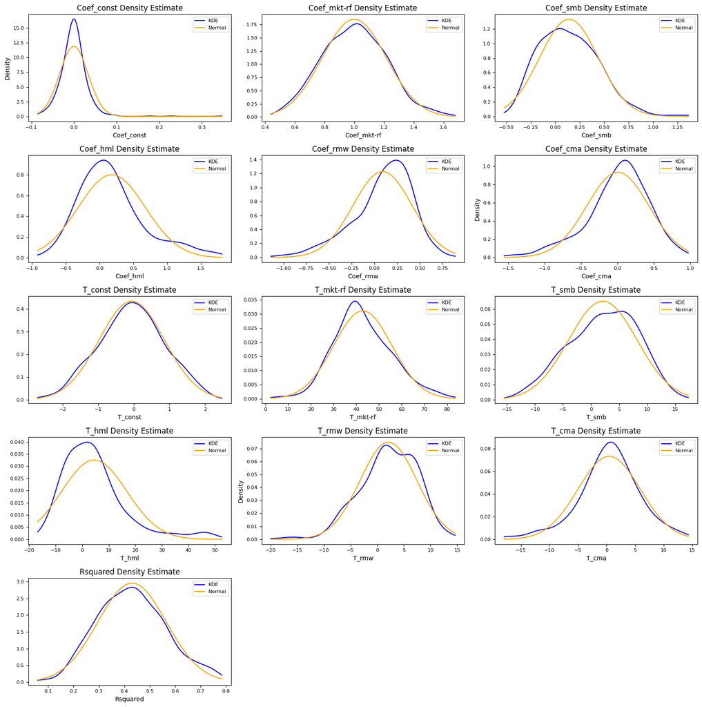

```python
# Define the statistics to plot
statistics = ['coef_const', 'coef_Mkt-RF', 'coef_SMB', 'coef_HML', 'coef_RMW', 'coef_CMA',
              't_const', 't_Mkt-RF', 't_SMB', 't_HML', 't_RMW', 't_CMA', 'rsquared']

# Create a 3x5 subplot layout (3 rows, 5 columns)
fig, axs = plt.subplots(5, 3, figsize=(16, 16))

# Loop over the columns and plot the KDE and normal distribution
for i, stat in enumerate(statistics):

    # Compute the KDE for the current statistic
    kde = gaussian_kde(results_df[stat])
    x_pdf = np.linspace(results_df[stat].min(), results_df[stat].max(), 100)
    y_pdf = kde(x_pdf)

    # Plot the normal distribution for the current statistic
    mean = np.mean(results_df[stat])
    variance = np.var(results_df[stat])
    y_norm = norm.pdf(x_pdf, loc=mean, scale=np.sqrt(variance))

    # Set the current subplot axis
    ax = axs[i // 3, i % 3]

    # Plot the KDE and normal distribution on the current subplot axis
    ax.plot(x_pdf, y_pdf, label='KDE', color='blue')
    ax.plot(x_pdf, y_norm, label='Normal', color='orange')

    # Add gridlines to the plot
    ax.grid(False)

    # Set the title and x-label of the plot
    ax.set_title(f'{stat.capitalize()} Density Estimate', fontsize=12)
    ax.set_xlabel(stat.capitalize(), fontsize=10)
    ax.legend(loc='upper right', fontsize=8)
    ax.tick_params(axis='both', which='major', labelsize=8)

    # Set the y-axis label on the leftmost subplots
    if i % 5 == 0:
        ax.set_ylabel('Density', fontsize=10)

    # Adjust the spacing between subplots
    fig.tight_layout()

# Hide empty subplots if the total number of columns is not a multiple of 5
if len(statistics) % 5 != 0:
    empty_subplots = 5 - (len(statistics) % 5)
    for i in range(1, empty_subplots + 1):
        fig.delaxes(axs[-1, -i])

# Display the plot
plt.show()
```

# **Question 4**

```python
# Creating a dataframe for all the sectors
sector_df = pd.DataFrame(columns = data.columns)
```

```python
from tqdm import tqdm

# Creating an empty list to add the sectors
sector_list = []

# Loop through all the stocks and get their sectors
for stock in tqdm(data.columns):
    try:
      sector_list.append(yf.Ticker(stock).info['sector'])
    except KeyError:
      sector_list.append('None')

sector_df.loc['sector',:] = sector_list
```

```python
# Transpose the matrix to adjust format
sector_df = sector_df.T

# Print the dataframe
sector_df
```

|  | sector |
| --- | --- |
| A | Healthcare |
| AAL | Industrials |
| AAP | Consumer Cyclical |
| AAPL | Technology |
| ABBV | Healthcare |
| ... | ... |
| YUM | Consumer Cyclical |
| ZBH | Healthcare |
| ZBRA | Technology |
| ZION | Financial Services |
| ZTS | Healthcare |

501 rows × 1 columns

```python
# Checking to see how many companies do not have a sector associated with them
sector_df.value_counts()
```

```
sector
Technology                74
Industrials               69
Financial Services        66
Healthcare                66
Consumer Cyclical         59
Consumer Defensive        36
Real Estate               31
Utilities                 30
Communication Services    24
Energy                    23
Basic Materials           22
None                       1
dtype: int64
```

```python
# Making a dataframe with just the coefficients
coeff_df = results_df[['coef_const', 'coef_Mkt-RF', 'coef_SMB', 'coef_HML', 'coef_RMW', 'coef_CMA']]

# Appending sector
coeff_df = coeff_df.join(sector_df)

# Viewing dataframe
coeff_df
```

|  | coef_const | coef_Mkt-RF | coef_SMB | coef_HML | coef_RMW | coef_CMA | sector |
| --- | --- | --- | --- | --- | --- | --- | --- |
| A | -0.001773 | 1.148522 | 0.043233 | -0.176370 | -0.233744 | 0.126144 | Healthcare |
| AAL | -0.025664 | 1.274175 | 0.835880 | 0.771863 | 0.241690 | -0.354739 | Industrials |
| AAP | -0.015446 | 0.842513 | 0.329174 | 0.038410 | 0.583610 | 0.039660 | Consumer Cyclical |
| AAPL | 0.025627 | 1.178940 | -0.175058 | -0.496573 | 0.595460 | -0.023434 | Technology |
| ABBV | 0.028802 | 0.792061 | -0.140258 | -0.128024 | 0.081595 | 0.368988 | Healthcare |
| ... | ... | ... | ... | ... | ... | ... | ... |
| YUM | 0.008259 | 0.856001 | -0.030305 | 0.042755 | 0.327835 | 0.066479 | Consumer Cyclical |
| ZBH | -0.017895 | 0.861004 | 0.193697 | 0.167856 | 0.117278 | -0.168369 | Healthcare |
| ZBRA | 0.006401 | 1.202621 | 0.417548 | -0.264469 | 0.188004 | -0.103440 | Technology |
| ZION | -0.002032 | 1.051078 | 0.338708 | 1.633707 | -0.552788 | -0.945926 | Financial Services |
| ZTS | 0.015335 | 0.919687 | -0.158877 | -0.288737 | 0.171654 | -0.047969 | Healthcare |

501 rows × 7 columns

```python
coeff_df.info()
```

```
<class 'pandas.core.frame.DataFrame'>
Index: 501 entries, A to ZTS
Data columns (total 7 columns):
 #   Column       Non-Null Count  Dtype
---  ------       --------------  -----
 0   coef_const   501 non-null    float64
 1   coef_Mkt-RF  501 non-null    float64
 2   coef_SMB     501 non-null    float64
 3   coef_HML     501 non-null    float64
 4   coef_RMW     501 non-null    float64
 5   coef_CMA     501 non-null    float64
 6   sector       501 non-null    object
dtypes: float64(6), object(1)
memory usage: 47.5+ KB
```

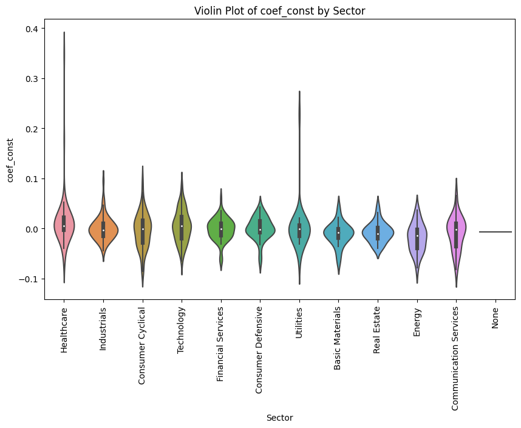

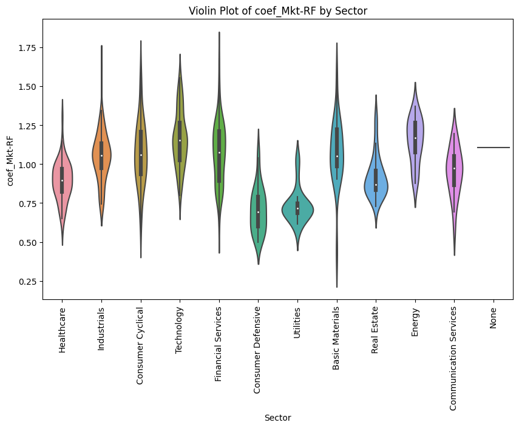

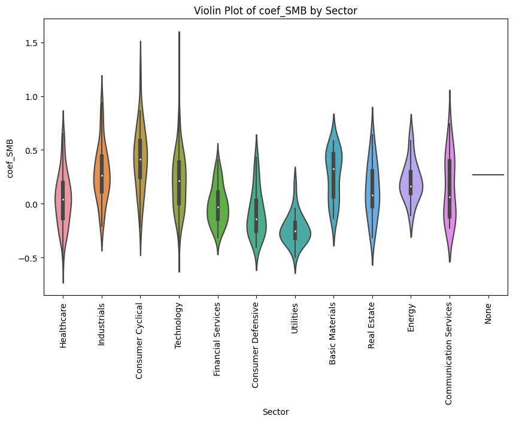

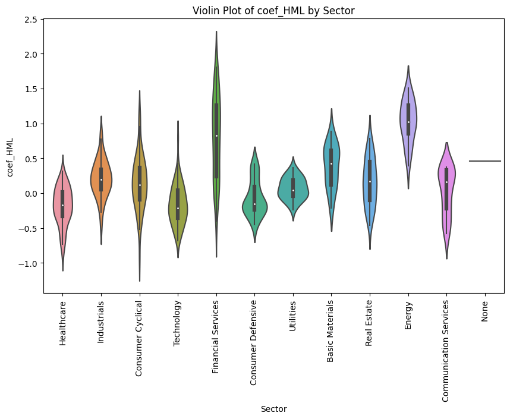

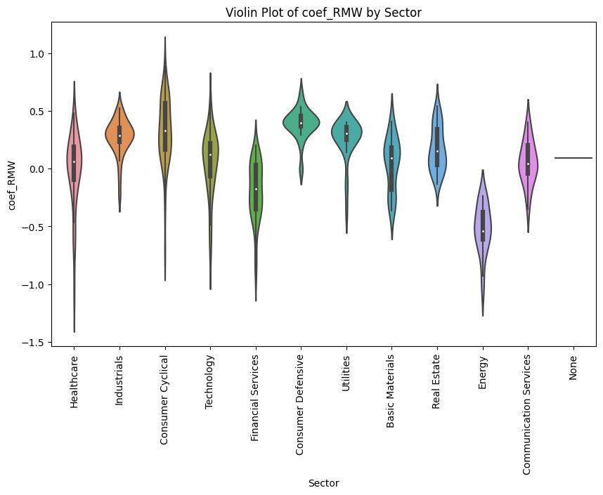

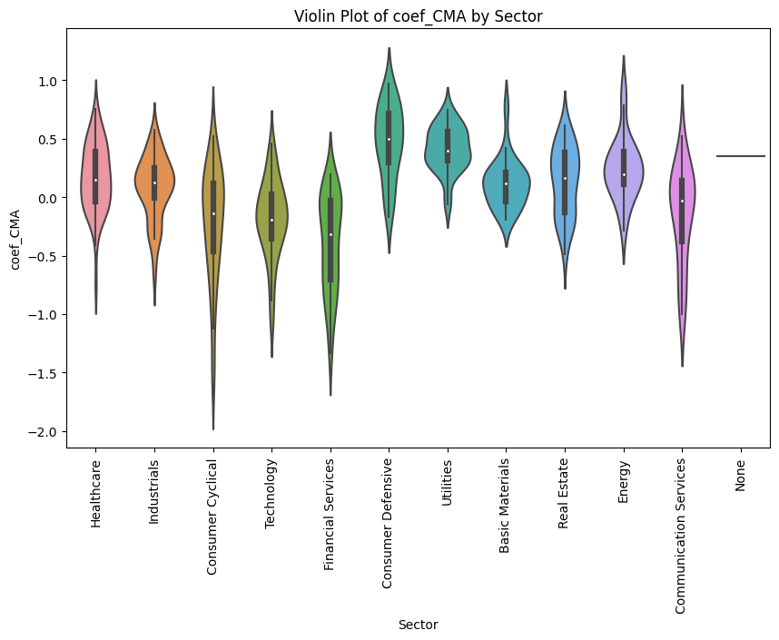

```python
# List of coefficients
coefficients = ['coef_const', 'coef_Mkt-RF', 'coef_SMB', 'coef_HML', 'coef_RMW', 'coef_CMA']

# Create a violin plot for each coefficient
for coefficient in coefficients:
    plt.figure(figsize=(10, 6))
    ax = sns.violinplot(data=coeff_df, x='sector', y=coefficient)
    plt.title(f'Violin Plot of {coefficient} by Sector')
    plt.xlabel('Sector')
    plt.ylabel(coefficient)

    # Rotate x-axis labels
    ax.set_xticklabels(ax.get_xticklabels(), rotation=90)

    plt.show()
```

# **Question 6**

```python
# Getting the values of the estimated constants from the results dataframe and sorting
alphas = results_df['coef_const'].sort_values(ascending=True)

# Getting 5 companies with highest estimated constant (last 5 elements in series)
top5 = alphas[-5:]

# Getting 5 companies with lowest estimated constant
bottom5 = alphas[:5]
```

```python
# Displaying 5 companies with highest alpha
for ticker, value in top5.items():
    company_name = yf.Ticker(ticker).info['longName']
    print(f"Company: {company_name}, Alpha Value: {value}")
```

```
Company: Tesla, Inc., Alpha Value: 0.09392974381780334
Company: Carrier Global Corporation, Alpha Value: 0.09554646740628528
Company: Moderna, Inc., Alpha Value: 0.17746099486445224
Company: Constellation Energy Corporation, Alpha Value: 0.2276694025261672
Company: GE HealthCare Technologies Inc., Alpha Value: 0.34742386121874713
```

```python
# Displaying 5 companies with lowest alpha
for ticker, value in bottom5.items():
    company_name = yf.Ticker(ticker).info['longName']
    print(f"Company: {company_name}, Alpha Value: {value}")
```

```
Company: Norwegian Cruise Line Holdings Ltd., Alpha Value: -0.08536242765604006
Company: DISH Network Corporation, Alpha Value: -0.0816953424668239
Company: Carnival Corporation & plc, Alpha Value: -0.08012918236474885
Company: APA Corporation, Alpha Value: -0.07858327182713251
Company: WestRock Company, Alpha Value: -0.07642765856697423
```

**Alpha Interpretation**

In the Fama-French model, alpha represents "excess return". It measures the investment's ability to beat the market.

1. **High Alpha**: If the estimated alpha is high and significantly positive, it suggests that the asset or portfolio has outperformed the expected return based on the systematic factors in the model. It implies that the asset or portfolio has generated higher returns than what would be predicted by its exposure to market risk, size, value, profitability, and investment factors. A high alpha is often interpreted as a sign of superior performance or skill in generating excess returns.
1. **Low Alpha**: Conversely, if the estimated alpha is low and significantly negative, it indicates that the asset or portfolio has underperformed the expected return based on the systematic factors. It suggests that the asset or portfolio has generated lower returns than what would be predicted by its exposure to the systematic risks in the model. A low alpha might imply that the asset or portfolio has experienced poor performance or has been unable to generate excess returns beyond what is explained by the systematic factors.

**Note**: If a given investment or portfolio manages to post stronger returns than comparable investments in the market at large, this investment has some value that an investor’s market analysis hasn’t captured. The same holds true in reverse for unexpectedly weak returns. This is expressed as the investment’s “alpha.”

# **Question 8**

```python
# Compute next day excess returns

next_day_sp_df = sp_df.shift(-1).iloc[:-1,:]
next_day_ff_df = ff_df[['RF']].shift(-1).iloc[:-1,:]
excess_returns = next_day_sp_df.sub(next_day_ff_df['RF'], axis=0)

results = []

# Create empty dictionaries for storing the results
params_dict = {}
tvalues_dict = {}

for column in excess_returns:
    Y = excess_returns[column]
    X = sm.add_constant(ff_df[['Mkt-RF', 'SMB', 'HML', 'RMW', 'CMA']].iloc[:-1,:])
    model = sm.OLS(Y, X, missing='drop')  # drop missing values
    result = model.fit()

    # Store the parameters and t-values in separate dictionaries
    params_dict[column] = result.params
    tvalues_dict[column] = result.tvalues

    # Append the results to the main list
    results.append({
        'stock': column,
        'rsquared': result.rsquared
    })

# Convert the dictionaries to dataframes
params_df = pd.DataFrame(params_dict).T
tvalues_df = pd.DataFrame(tvalues_dict).T
rsquared_df = pd.DataFrame.from_dict(results)

# Set index of rsquared df
rsquared_df = rsquared_df.set_index('stock')

# Rename columns
params_df.columns = ['coef_const', 'coef_Mkt-RF', 'coef_SMB', 'coef_HML', 'coef_RMW', 'coef_CMA']
tvalues_df.columns = ['t_const', 't_Mkt-RF', 't_SMB', 't_HML', 't_RMW', 't_CMA']

# Merge dataframes on index
next_day_results_df = pd.concat([params_df, tvalues_df, rsquared_df], axis=1)
next_day_results_df
```

|  | coef_const | coef_Mkt-RF | coef_SMB | coef_HML | coef_RMW | coef_CMA | t_const | t_Mkt-RF | t_SMB | t_HML | t_RMW | t_CMA | rsquared |
| --- | --- | --- | --- | --- | --- | --- | --- | --- | --- | --- | --- | --- | --- |
| A | 0.060574 | -0.095630 | 0.123516 | -0.068217 | -0.003772 | -0.102338 | 1.920072 | -3.172339 | 2.166257 | -1.258872 | -0.049709 | -0.983090 | 0.005211 |
| AAL | 0.023994 | -0.000798 | 0.402284 | -0.103481 | 0.597456 | -0.177147 | 0.421881 | -0.014678 | 3.913667 | -1.059283 | 4.367978 | -0.943963 | 0.008307 |
| AAP | 0.042064 | -0.152473 | 0.070388 | 0.030075 | 0.014302 | -0.166745 | 1.224405 | -4.644727 | 1.133625 | 0.509656 | 0.173096 | -1.470932 | 0.006882 |
| AAPL | 0.101999 | -0.140946 | 0.118647 | -0.083329 | -0.024846 | -0.100716 | 3.264820 | -4.721440 | 2.101268 | -1.552830 | -0.330678 | -0.976992 | 0.009229 |
| ABBV | 0.075725 | -0.074822 | 0.121338 | 0.000310 | 0.049407 | -0.085482 | 2.245673 | -2.328887 | 2.037582 | 0.005586 | 0.622262 | -0.801609 | 0.003410 |
| ... | ... | ... | ... | ... | ... | ... | ... | ... | ... | ... | ... | ... | ... |
| YUM | 0.057222 | -0.077235 | 0.082621 | -0.133560 | 0.066796 | 0.014210 | 2.144979 | -3.029895 | 1.713592 | -2.914718 | 1.041106 | 0.161425 | 0.007180 |
| ZBH | 0.020678 | 0.001270 | 0.080962 | -0.123310 | 0.149228 | 0.032671 | 0.723889 | 0.046536 | 1.568229 | -2.513206 | 2.172214 | 0.346621 | 0.003238 |
| ZBRA | 0.075713 | -0.100016 | 0.119832 | -0.017176 | -0.029472 | -0.095498 | 1.925697 | -2.662215 | 1.686367 | -0.254329 | -0.311679 | -0.736106 | 0.002784 |
| ZION | 0.029693 | -0.083240 | 0.156125 | -0.063505 | 0.077236 | -0.045837 | 0.744480 | -2.184139 | 2.165834 | -0.926963 | 0.805189 | -0.348288 | 0.002826 |
| ZTS | 0.070734 | -0.114253 | 0.079148 | -0.075130 | 0.035324 | -0.206581 | 2.226867 | -3.784992 | 1.413596 | -1.441665 | 0.473460 | -2.062041 | 0.010060 |

501 rows × 13 columns

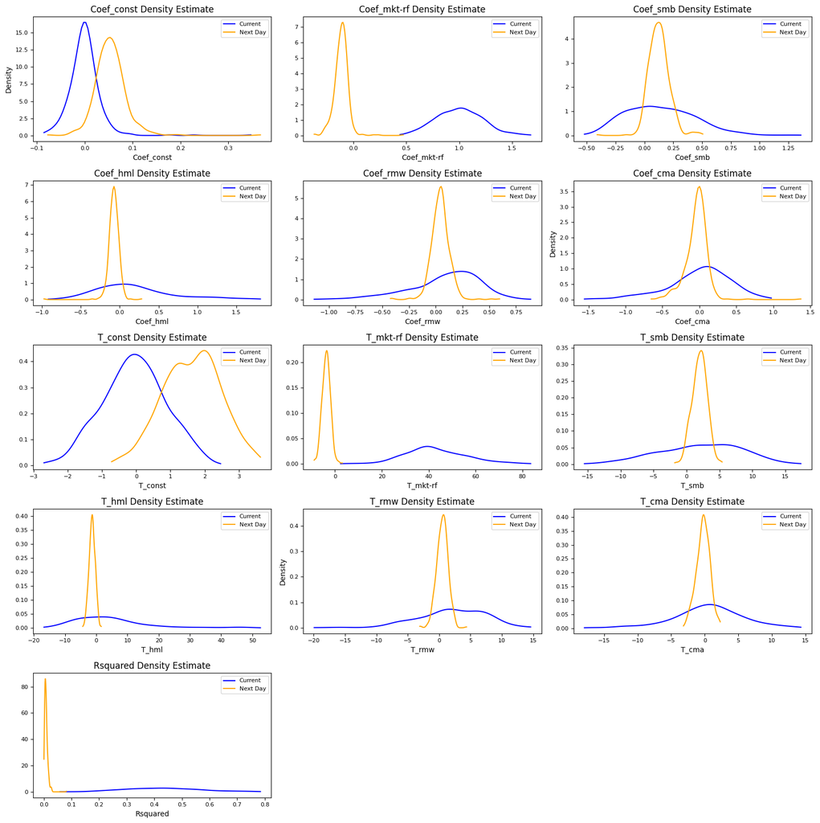

```python
# Define the statistics to plot
statistics = ['coef_const', 'coef_Mkt-RF', 'coef_SMB', 'coef_HML', 'coef_RMW', 'coef_CMA',
              't_const', 't_Mkt-RF', 't_SMB', 't_HML', 't_RMW', 't_CMA', 'rsquared']

# Create a 3x5 subplot layout (3 rows, 5 columns)
fig, axs = plt.subplots(5, 3, figsize=(16, 16))

# Loop over the columns and plot the KDE and normal distribution
for i, stat in enumerate(statistics):

    # Set the current subplot axis
    ax = axs[i // 3, i % 3]

    # Compute the KDE for the current statistic
    kde = gaussian_kde(results_df[stat])
    x_pdf = np.linspace(results_df[stat].min(), results_df[stat].max(), 100)
    y_pdf = kde(x_pdf)

    # Plot the KDE and normal distribution on the current subplot axis
    ax.plot(x_pdf, y_pdf, label='Current', color='blue')

    # Compute the KDE for the next day statistic
    kde = gaussian_kde(next_day_results_df[stat])
    x_pdf = np.linspace(next_day_results_df[stat].min(), next_day_results_df[stat].max(), 100)
    y_pdf = kde(x_pdf)

    # Plot the KDE and normal distribution on the current subplot axis
    ax.plot(x_pdf, y_pdf, label='Next Day', color='orange')

    # Add gridlines to the plot
    ax.grid(False)

    # Set the title and x-label of the plot
    ax.set_title(f'{stat.capitalize()} Density Estimate', fontsize=12)
    ax.set_xlabel(stat.capitalize(), fontsize=10)
    ax.legend(loc='upper right', fontsize=8)
    ax.tick_params(axis='both', which='major', labelsize=8)

    # Set the y-axis label on the leftmost subplots
    if i % 5 == 0:
        ax.set_ylabel('Density', fontsize=10)

    # Adjust the spacing between subplots
    fig.tight_layout()

# Hide empty subplots if the total number of columns is not a multiple of 5
if len(statistics) % 5 != 0:
    empty_subplots = 5 - (len(statistics) % 5)
    for i in range(1, empty_subplots + 1):
        fig.delaxes(axs[-1, -i])

# Display the plot
plt.show()
```